# Modeling Swire Coca Cola

### 3.4 Model Evaluation Through Visualizations and Insights

#### 3.4.1. Regional Differences in Machine Failure Patterns:

Visualizing failure rates by region could provide insight into how failure rates differ across regions and what factors might contribute to this.

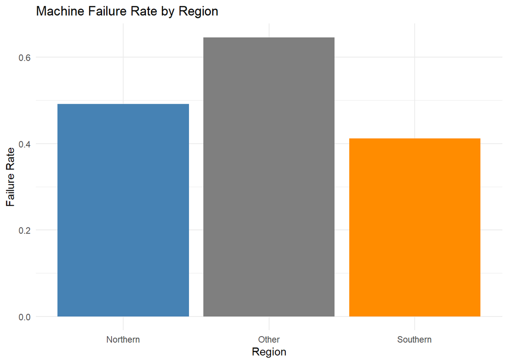

```r
# Plot failure rate by region
region_failure_rate <- data %>%
  group_by(Region) %>%
  summarise(Failure_Rate = mean(Failure))

ggplot(region_failure_rate, aes(x = Region, y = Failure_Rate, fill = Region)) +
  geom_bar(stat = "identity", show.legend = FALSE) +
  theme_minimal() +
  labs(title = "Machine Failure Rate by Region",
       x = "Region",
       y = "Failure Rate") +
  scale_fill_manual(values = c("Northern" = "steelblue", "Southern" = "darkorange"))
```

#### 3.4.2. Model Performance Comparison:

You already have the accuracy calculations and bar plots for model performance by region. It’s important to ensure that both regions are being compared side by side for each model to make this comparison clearer.

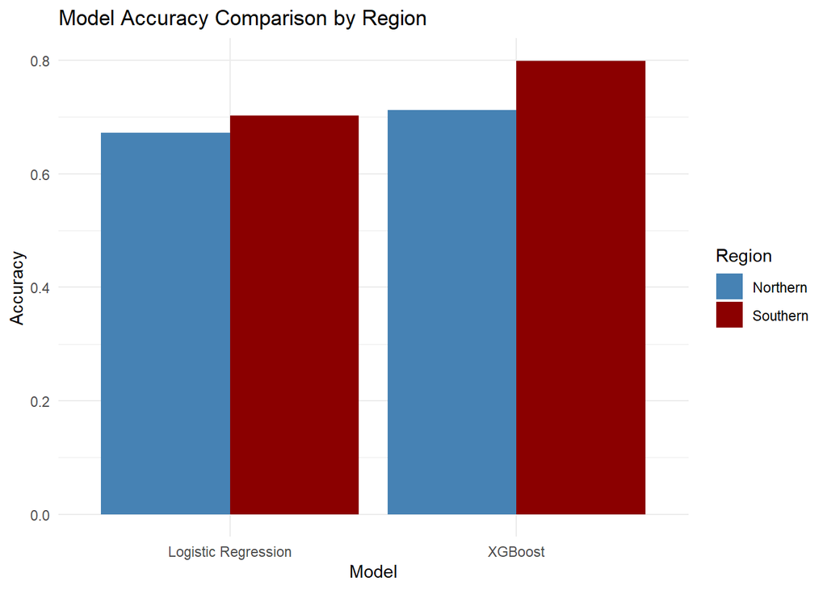

```r
# Combine northern and southern model results into a single data frame
combined_results <- rbind(
  data.frame(Region = "Northern", northern_results),
  data.frame(Region = "Southern", southern_results)
)

# Visualize model accuracy comparison by region
ggplot(combined_results, aes(x = Model, y = Accuracy, fill = Region)) +
  geom_bar(stat = "identity", position = "dodge") +
  theme_minimal() +
  labs(title = "Model Accuracy Comparison by Region",
       x = "Model",
       y = "Accuracy") +
  scale_fill_manual(values = c("Northern" = "steelblue", "Southern" = "darkred"))
```

#### 3.4.3. Feature Importance Comparison for Models:

To identify which features most influence the model’s predictions for each region, you can visualize the feature importance for the Random Forest and XGBoost models. This will show what drives machine failures in different regions.

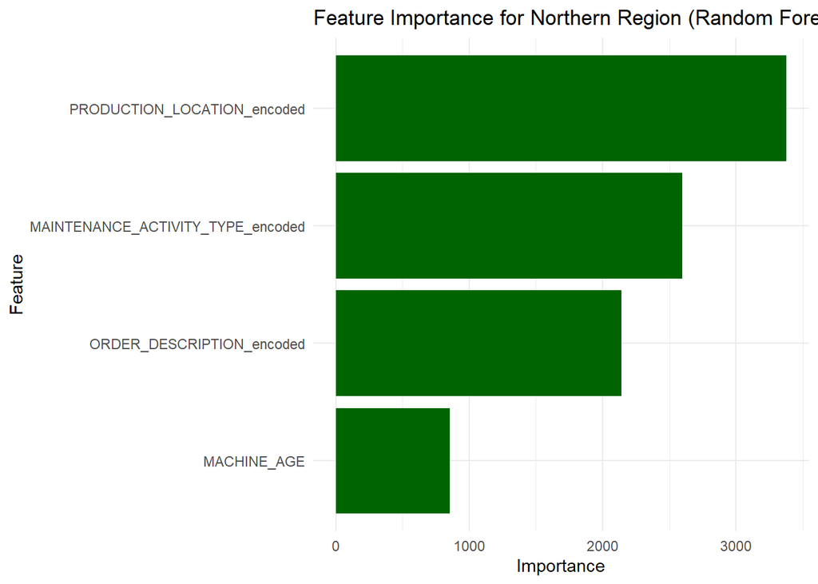

```r
# Feature importance for Random Forest (Northern Region)
# The importance values should be a data frame
rf_northern_importance <- data.frame(Feature = rownames(rf_northern_model$importance),
                                     Importance = rf_northern_model$importance[, 1])

# Feature importance for XGBoost (Northern Region)
xgb_northern_importance <- xgb.importance(feature_names = colnames(xgb_northern_data), model = xgb_northern_model)

# Plot feature importance for Northern region (Random Forest)
ggplot(rf_northern_importance, aes(x = reorder(Feature, Importance), y = Importance)) +
  geom_bar(stat = "identity", fill = "darkgreen") +
  coord_flip() +
  theme_minimal() +
  labs(title = "Feature Importance for Northern Region (Random Forest)",
       x = "Feature",
       y = "Importance")
```

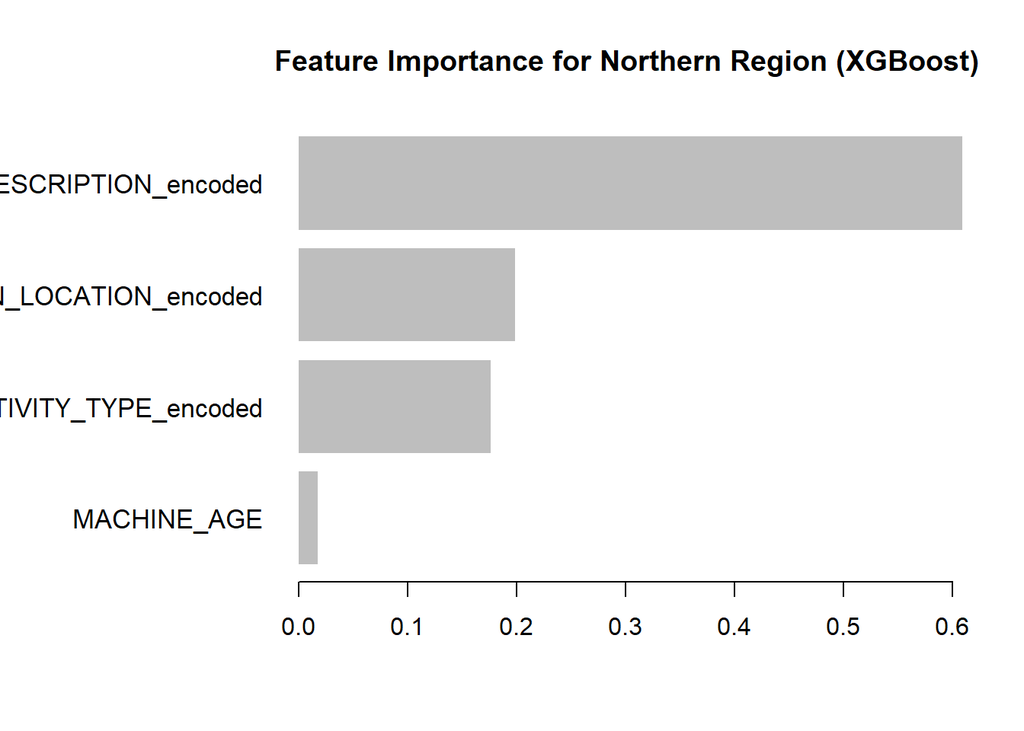

```r
# Plot feature importance for XGBoost in Northern Region
# For XGBoost, use `xgb.plot.importance` function to visualize the feature importance
xgb.plot.importance(xgb_northern_importance, main = "Feature Importance for Northern Region (XGBoost)")
```

#### 3.4.4. Failure Rates or Patterns Influencing Model Predictions:

You can use the coefficients from logistic regression models to visualize how different factors affect machine failure in each region.

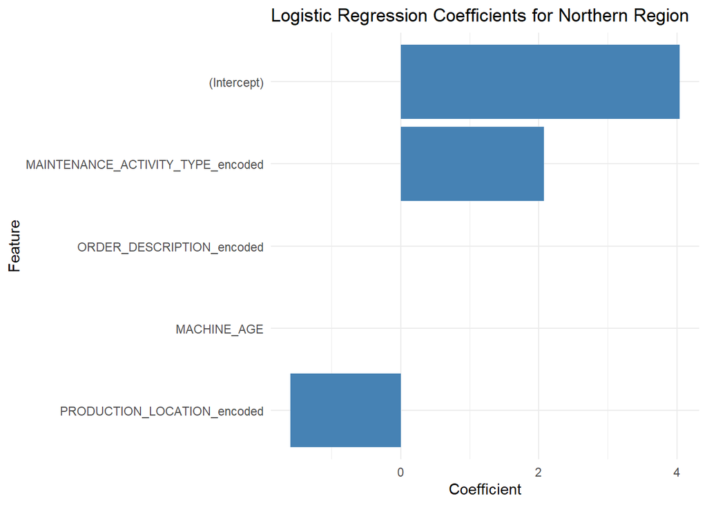

```r
# Coefficients from Logistic Regression for Northern Region
logistic_coefs_northern <- summary(logistic_northern)$coefficients[, 1]
logistic_coefs_northern <- data.frame(Feature = names(logistic_coefs_northern),
                                      Coefficient = logistic_coefs_northern)

# Plot coefficients for Northern region logistic regression
ggplot(logistic_coefs_northern, aes(x = reorder(Feature, Coefficient), y = Coefficient)) +
  geom_bar(stat = "identity", fill = "steelblue") +
  coord_flip() +
  theme_minimal() +
  labs(title = "Logistic Regression Coefficients for Northern Region",
       x = "Feature",
       y = "Coefficient")
```